# CARDIOVASCULAR DISEASE : ANALYSIS OF CAUSES AND PREDICTION

### Reg. No: 18BCE1039

### Name: PARTH CHOUDHARY

## Setup

### Load packages

```r
library(dplyr)
```

```r
library(ggplot2)
library(GGally)
```

### Load data

```r
cardio=read.csv("cardio_train.csv")
```

## What problem are you trying to solve?

```r
#To find out how different factors affects the cardiovascular disease
#and predict if someone have the disease or not based on these factors.
```

## What data have you chosen?(Chosen Dataset, Source of dataset, Description of dataset, basic commands to describe dataset)

### Dataset chosen : Cardiovascular Disease Dataset (CSV file)

### Source : www.kaggle.com (https://www.kaggle.com/sulianova/cardiovascular-disease-dataset)

### Description :

### There are 3 types of input features:

### 1 Objective: factual information;

### 2 Examination: results of medical examination;

### 3 Subjective: information given by the patient.

### Features:

```r
#Feature | Variable Type | Variable | Value Type

#Age | Objective Feature | age | int (days)
#Height | Objective Feature | height | int (cm) |
#Weight | Objective Feature | weight | float (kg) |
#Gender | Objective Feature | gender | categorical code |
#Systolic blood pressure | Examination Feature | ap_hi | int |
#Diastolic blood pressure | Examination Feature | ap_lo | int |
#Cholesterol | Examination Feature | cholesterol | 1: normal, 2: above normal, 3: well above normal |
#Glucose | Examination Feature | gluc | 1: normal, 2: above normal, 3: well above normal |
#Smoking | Subjective Feature | smoke | binary |
#Alcohol intake | Subjective Feature | alco | binary |
#Physical activity | Subjective Feature | active | binary |
#Presence or absence of cardiovascular disease | Target Variable | cardio | binary |
```

# Description using basic commands

```r
#No. of rows :
nrow(cardio)
```

```
## [1] 70000
```

```r
#No. of columns :
ncol(cardio)
```

```
## [1] 13
```

```r
#Displaying the structure of the dataset :
str(cardio)
```

```
## 'data.frame':    70000 obs. of  13 variables:
##  $ id         : int  0 1 2 3 4 8 9 12 13 14 ...
##  $ age        : int  18393 20228 18857 17623 17474 21914 22113 22584 17668 19834 ...
##  $ gender     : int  2 1 1 2 1 1 1 2 1 1 ...
##  $ height     : int  168 156 165 169 156 151 157 178 158 164 ...
##  $ weight     : num  62 85 64 82 56 67 93 95 71 68 ...
##  $ ap_hi      : int  110 140 130 150 100 120 130 130 110 110 ...
##  $ ap_lo      : int  80 90 70 100 60 80 80 90 70 60 ...
##  $ cholesterol: int  1 3 3 1 1 2 3 3 1 1 ...
##  $ gluc       : int  1 1 1 1 1 2 1 3 1 1 ...
##  $ smoke      : int  0 0 0 0 0 0 0 0 0 0 ...
##  $ alco       : int  0 0 0 0 0 0 0 0 0 0 ...
##  $ active     : int  1 1 0 1 0 0 1 1 1 0 ...
##  $ cardio     : int  0 1 1 1 0 0 0 1 0 0 ...
```

```r
#Displaying class and type of the cardio dataframe :
class(cardio)
```

```
## [1] "data.frame"
```

```r
typeof(cardio)
```

```
## [1] "list"
```

```r
#Dimension of dataframe :
dim(cardio)
```

```
## [1] 70000    13
```

```r
#Column names of all columns present in dataframe :
names(cardio)
```

```
##  [1] "id"          "age"         "gender"      "height"      "weight"
##  [6] "ap_hi"       "ap_lo"       "cholesterol" "gluc"        "smoke"
## [11] "alco"        "active"      "cardio"
```

```r
#Displaying the summary of the dataset :
summary(cardio)
```

```
##        id             age            gender         height
##  Min.   :    0   Min.   :10798   Min.   :1.00   Min.   : 55.0
##  1st Qu.:25007   1st Qu.:17664   1st Qu.:1.00   1st Qu.:159.0
##  Median :50002   Median :19703   Median :1.00   Median :165.0
##  Mean   :49972   Mean   :19469   Mean   :1.35   Mean   :164.4
##  3rd Qu.:74889   3rd Qu.:21327   3rd Qu.:2.00   3rd Qu.:170.0
##  Max.   :99999   Max.   :23713   Max.   :2.00   Max.   :250.0
##      weight           ap_hi             ap_lo           cholesterol
##  Min.   : 10.00   Min.   : -150.0   Min.   :  -70.00   Min.   :1.000
##  1st Qu.: 65.00   1st Qu.:  120.0   1st Qu.:   80.00   1st Qu.:1.000
##  Median : 72.00   Median :  120.0   Median :   80.00   Median :1.000
##  Mean   : 74.21   Mean   :  128.8   Mean   :   96.63   Mean   :1.367
##  3rd Qu.: 82.00   3rd Qu.:  140.0   3rd Qu.:   90.00   3rd Qu.:2.000
##  Max.   :200.00   Max.   :16020.0   Max.   :11000.00   Max.   :3.000
##       gluc           smoke              alco             active
##  Min.   :1.000   Min.   :0.00000   Min.   :0.00000   Min.   :0.0000
##  1st Qu.:1.000   1st Qu.:0.00000   1st Qu.:0.00000   1st Qu.:1.0000
##  Median :1.000   Median :0.00000   Median :0.00000   Median :1.0000
##  Mean   :1.226   Mean   :0.08813   Mean   :0.05377   Mean   :0.8037
##  3rd Qu.:1.000   3rd Qu.:0.00000   3rd Qu.:0.00000   3rd Qu.:1.0000
##  Max.   :3.000   Max.   :1.00000   Max.   :1.00000   Max.   :1.0000
##      cardio
##  Min.   :0.0000
##  1st Qu.:0.0000
##  Median :0.0000
##  Mean   :0.4997
##  3rd Qu.:1.0000
##  Max.   :1.0000
```

```r
#Displaying the first six rows of the cardio dataset :
head(cardio)
```

```
##   id   age gender height weight ap_hi ap_lo cholesterol gluc smoke alco active
## 1  0 18393      2    168     62   110    80           1    1     0    0      1
## 2  1 20228      1    156     85   140    90           3    1     0    0      1
## 3  2 18857      1    165     64   130    70           3    1     0    0      0
## 4  3 17623      2    169     82   150   100           1    1     0    0      1
## 5  4 17474      1    156     56   100    60           1    1     0    0      0
## 6  8 21914      1    151     67   120    80           2    2     0    0      0
##   cardio
## 1      0
## 2      1
## 3      1
## 4      1
## 5      0
## 6      0
```

```r
#Displaying the last six rows of the cardio dataset :
tail(cardio)
```

```
##          id   age gender height weight ap_hi ap_lo cholesterol gluc smoke alco
## 69995 99992 21074      1    165     80   150    80           1    1     0    0
## 69996 99993 19240      2    168     76   120    80           1    1     1    0
## 69997 99995 22601      1    158    126   140    90           2    2     0    0
## 69998 99996 19066      2    183    105   180    90           3    1     0    1
## 69999 99998 22431      1    163     72   135    80           1    2     0    0
## 70000 99999 20540      1    170     72   120    80           2    1     0    0
##       active cardio
## 69995      1      1
## 69996      1      0
## 69997      1      1
## 69998      0      1
## 69999      0      1
## 70000      1      0
```

## Frame your objectives

```r
#1. Exploratory Data Analysis (EDA) with Data Visualization
#2. Find correlation between the factors(causes) and the disease
#3. Predict the occurrence of disease based on the factors using ML Model.
```

## Is there any work previously reported on the problem and the data? If so, discuss it here.

```r
# Yes, Exploratory Data Analysis  as well as Comparison of ML Models in python has been done on this data.
#What I want to do (extra)except the reported work is to also correlate the disease causing factors among themselves to find if they indirectly affect the disease or not.

# Reference: https://www.kaggle.com/sulianova/cardiovascular-disease-dataset
```

# Review-2 : Exploratory Data Analysis with Visualization

## Data Preparation (Data Cleaning)

```r
# Checking if there are any NAs or missing values in a dataset?
colSums(is.na(cardio))
```

```
##          id         age      gender      height      weight       ap_hi
##           0           0           0           0           0           0
##       ap_lo cholesterol        gluc       smoke        alco      active
##           0           0           0           0           0           0
##      cardio
##           0
```

```r
# So there are no N/A values.
```

## Removing outliers

### Anomalies and entries with unreasonable values are removed from the original dataset: extreme weight and height values, as well as extreme diastolic and systolic blood pressure values, for example, if we look height and weight columns, we will notice that minimum height is 55 cm and minimum weight is 10 kg. That has to be an error, since minimum age is 10798 days, which equals to 29 years. On the other hand, the maximum height is 250 cm and the highest weight is 200 kg, which might be irrelevant, when generalizing data. To deal with these errors.Removing values in which ap_hi is lower than ap_lo.

```r
summary(cardio)
```

```
##        id             age            gender         height
##  Min.   :    0   Min.   :10798   Min.   :1.00   Min.   : 55.0
##  1st Qu.:25007   1st Qu.:17664   1st Qu.:1.00   1st Qu.:159.0
##  Median :50002   Median :19703   Median :1.00   Median :165.0
##  Mean   :49972   Mean   :19469   Mean   :1.35   Mean   :164.4
##  3rd Qu.:74889   3rd Qu.:21327   3rd Qu.:2.00   3rd Qu.:170.0
##  Max.   :99999   Max.   :23713   Max.   :2.00   Max.   :250.0
##      weight           ap_hi             ap_lo           cholesterol
##  Min.   : 10.00   Min.   : -150.0   Min.   :  -70.00   Min.   :1.000
##  1st Qu.: 65.00   1st Qu.:  120.0   1st Qu.:   80.00   1st Qu.:1.000
##  Median : 72.00   Median :  120.0   Median :   80.00   Median :1.000
##  Mean   : 74.21   Mean   :  128.8   Mean   :   96.63   Mean   :1.367
##  3rd Qu.: 82.00   3rd Qu.:  140.0   3rd Qu.:   90.00   3rd Qu.:2.000
##  Max.   :200.00   Max.   :16020.0   Max.   :11000.00   Max.   :3.000
##       gluc           smoke              alco             active
##  Min.   :1.000   Min.   :0.00000   Min.   :0.00000   Min.   :0.0000
##  1st Qu.:1.000   1st Qu.:0.00000   1st Qu.:0.00000   1st Qu.:1.0000
##  Median :1.000   Median :0.00000   Median :0.00000   Median :1.0000
##  Mean   :1.226   Mean   :0.08813   Mean   :0.05377   Mean   :0.8037
##  3rd Qu.:1.000   3rd Qu.:0.00000   3rd Qu.:0.00000   3rd Qu.:1.0000
##  Max.   :3.000   Max.   :1.00000   Max.   :1.00000   Max.   :1.0000
##      cardio
##  Min.   :0.0000
##  1st Qu.:0.0000
##  Median :0.0000
##  Mean   :0.4997
##  3rd Qu.:1.0000
##  Max.   :1.0000
```

```r
cardio <- cardio[,2:13] # removing 'index' column
ap_cleaned <- cardio %>% filter(ap_hi>ap_lo)
height_cleaned <- ap_cleaned %>% filter(height >= 140,height <= 220)
weight_cleaned <- height_cleaned %>% filter(weight >= 30)
ap_cleaned2 <- weight_cleaned %>% filter(ap_lo >= 40,ap_lo <= 100)
cleaned_cardio <- ap_cleaned2 %>% filter(ap_hi >= 80 ,ap_hi <= 180)
summary(cleaned_cardio)
```

```
##       age            gender          height          weight        ap_hi
##  Min.   :10798   Min.   :1.000   Min.   :140.0   Min.   : 30   Min.   : 80.0
##  1st Qu.:17651   1st Qu.:1.000   1st Qu.:159.0   1st Qu.: 65   1st Qu.:120.0
##  Median :19699   Median :1.000   Median :165.0   Median : 72   Median :120.0
##  Mean   :19460   Mean   :1.348   Mean   :164.5   Mean   : 74   Mean   :126.1
##  3rd Qu.:21323   3rd Qu.:2.000   3rd Qu.:170.0   3rd Qu.: 82   3rd Qu.:140.0
##  Max.   :23713   Max.   :2.000   Max.   :207.0   Max.   :200   Max.   :180.0
##      ap_lo         cholesterol         gluc           smoke
##  Min.   : 40.00   Min.   :1.000   Min.   :1.000   Min.   :0.00000
##  1st Qu.: 80.00   1st Qu.:1.000   1st Qu.:1.000   1st Qu.:0.00000
##  Median : 80.00   Median :1.000   Median :1.000   Median :0.00000
##  Mean   : 80.95   Mean   :1.361   Mean   :1.224   Mean   :0.08751
##  3rd Qu.: 90.00   3rd Qu.:1.000   3rd Qu.:1.000   3rd Qu.:0.00000
##  Max.   :100.00   Max.   :3.000   Max.   :3.000   Max.   :1.00000
##       alco             active           cardio
##  Min.   :0.00000   Min.   :0.0000   Min.   :0.0000
##  1st Qu.:0.00000   1st Qu.:1.0000   1st Qu.:0.0000
##  Median :0.00000   Median :1.0000   Median :0.0000
##  Mean   :0.05285   Mean   :0.8035   Mean   :0.4905
##  3rd Qu.:0.00000   3rd Qu.:1.0000   3rd Qu.:1.0000
##  Max.   :1.00000   Max.   :1.0000   Max.   :1.0000
```

```r
#boxplot(cleaned_cardio$ap_lo,cleaned_cardio$ap_hi,col=c("Yellow","Red"),names=c("ap_lo","ap_hi"),main="Comparison of ap_lo & ap_hi")
```

### Calculating BMI (Body Mass Index) and getting the correlation plots

```r
cleaned_cardio$BMI=cleaned_cardio$weight/(cleaned_cardio$height/100)^2
a=ggcorr(cleaned_cardio,label = TRUE,label_alpha = TRUE)
b=ggcorr(cleaned_cardio,label = TRUE,label_alpha = TRUE,method = c("all.obs", "spearman"))
```

### Some categorical variables such as “cardio”, “active”, “alcohol” are treated as continuous variables in the original dataset. Thus, we need to make these variables categorical. Checking categorical variables in the dataset.

```r
cols = c("gender","cholesterol", "gluc", "smoke", "alco", "active","cardio")
cleaned_cardio[cols] = lapply(cleaned_cardio[cols], factor)
summary(cleaned_cardio)
```

```
##       age        gender        height          weight        ap_hi
##  Min.   :10798   1:44148   Min.   :140.0   Min.   : 30   Min.   : 80.0
##  1st Qu.:17651   2:23532   1st Qu.:159.0   1st Qu.: 65   1st Qu.:120.0
##  Median :19699             Median :165.0   Median : 72   Median :120.0
##  Mean   :19460             Mean   :164.5   Mean   : 74   Mean   :126.1
##  3rd Qu.:21323             3rd Qu.:170.0   3rd Qu.: 82   3rd Qu.:140.0
##  Max.   :23713             Max.   :207.0   Max.   :200   Max.   :180.0
##      ap_lo        cholesterol gluc      smoke     alco      active    cardio
##  Min.   : 40.00   1:50919     1:57629   0:61757   0:64103   0:13299   0:34483
##  1st Qu.: 80.00   2: 9086     2: 4926   1: 5923   1: 3577   1:54381   1:33197
##  Median : 80.00   3: 7675     3: 5125
##  Mean   : 80.95
##  3rd Qu.: 90.00
##  Max.   :100.00
##       BMI
##  Min.   :10.73
##  1st Qu.:23.88
##  Median :26.30
##  Mean   :27.39
##  3rd Qu.:30.10
##  Max.   :68.31
```

## Initial Analysis on variables

### The distribution of gender:

```r
Gender_Dist=table(cleaned_cardio$gender)
row.names(Gender_Dist)<-c("Female","Male")
Gender_Dist
```

```
##
## Female   Male
##  44148  23532
```

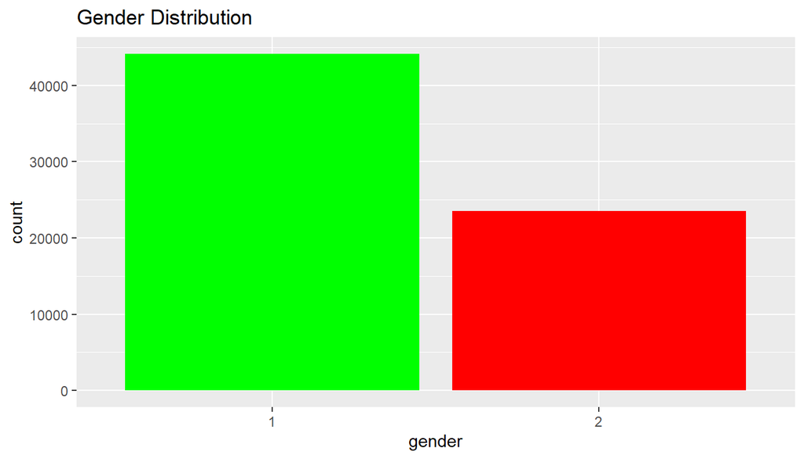

```r
ggplot(cleaned_cardio,aes(gender))+geom_bar(fill=c("green","red"))+labs(title = 'Gender Distribution')
```

### Alcohol consumption based on gender:

```r
x=table(cleaned_cardio$gender,cleaned_cardio$alco)
row.names(x)<-c("Female","Male")
colnames(x)<-c("Not Alcoholic","Alcoholic")
x
```

```
##
##          Not Alcoholic Alcoholic
##   Female         43045      1103
##   Male           21058      2474
```

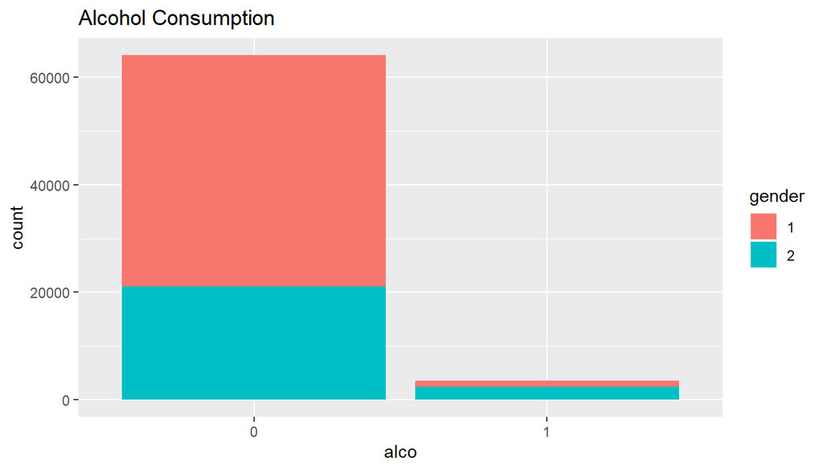

```r
ggplot(cleaned_cardio,aes(alco))+geom_bar(aes(fill=gender))+labs(title="Alcohol Consumption")
```

### Average weight distribution based on gender:

```r
cleaned_cardio%>%
  group_by(gender)%>%
  summarise(MeanWt=mean(weight))
```

```
## # A tibble: 2 x 2
##   gender MeanWt
##   <fct>   <dbl>
## 1 1        72.4
## 2 2        77.0
```

```r
# 1 represents women, 2 represents men
```

### To see how the target class is distributed among men and women:

```r
y=table(cleaned_cardio$gender,cleaned_cardio$cardio)
colnames(y)<-c("No Disease","Disease")
row.names(y)<-c("Female","Male")
y
```

```
##
##          No Disease Disease
##   Female      22574   21574
##   Male        11909   11623
```

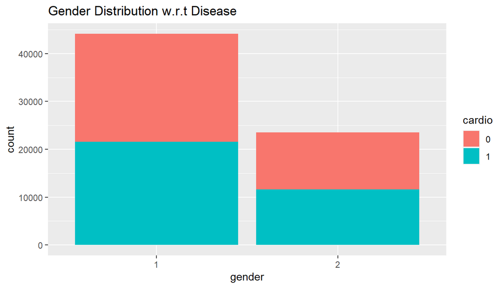

```r
ggplot(cleaned_cardio,aes(gender))+geom_bar(aes(fill=cardio))+labs(title = 'Gender Distribution w.r.t Disease')
```

### Checking how age is spread among target class, at what age does the number of people with CVD increase?

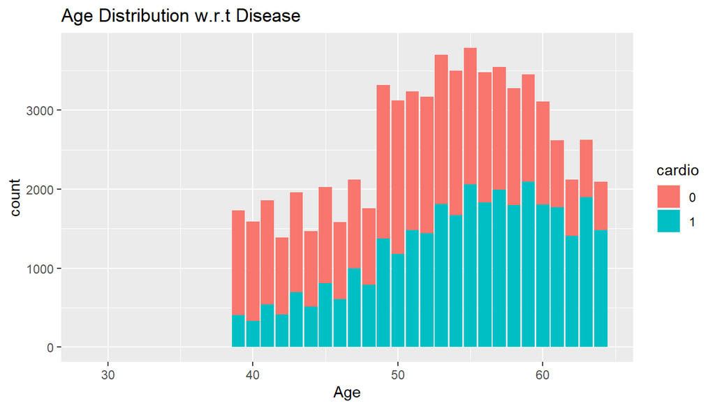

```r
options(digits=2)
agedis=as.integer(cleaned_cardio$age/365)
ggplot(cleaned_cardio,aes(x=agedis))+geom_bar(aes(fill=cardio))+labs(x='Age',title = 'Age Distribution w.r.t Disease')
```

```r
#It can be observed that people over 50 years of age are more likely to have the disease(CVD).
```

### Distribution Plot of cholestrol levels w.r.t disease

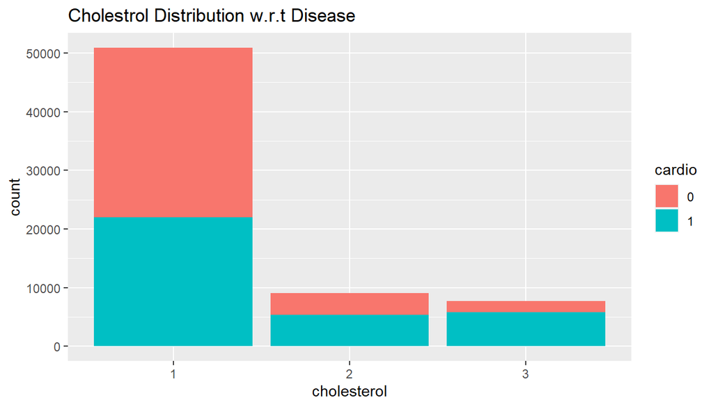

```r
ggplot(cleaned_cardio,aes(cholesterol))+geom_bar(aes(fill=cardio))+labs(title = 'Cholestrol Distribution w.r.t Disease')
```

```r
#From graph, we can see that 3rd level (well above high) has a very high ratio to cause the disease.
```

### Distribution Plot of people who smoke w.r.t disease

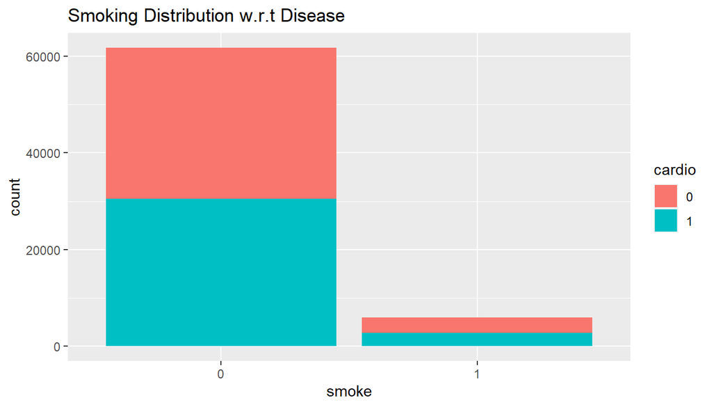

```r
ggplot(cleaned_cardio,aes(smoke))+geom_bar(aes(fill=cardio))+labs(title = 'Smoking Distribution w.r.t Disease')
```

```r
#From graph, we can see that distribution is similar for disease vs non-disease, and smoking factor is very small to cause the disease.
```

### Distribution Plot of people who consume alcohol w.r.t disease

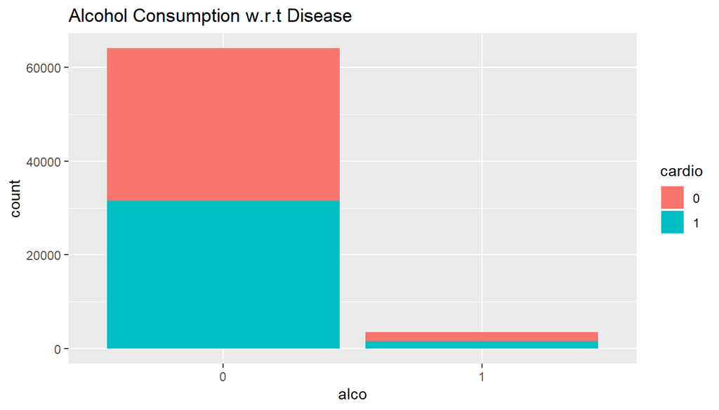

```r
ggplot(cleaned_cardio,aes(alco))+geom_bar(aes(fill=cardio))+labs(title = 'Alcohol Consumption w.r.t Disease')
```

```r
#From graph, we can see that distribution is similar for disease vs non-disease, and alcohol factor is very small to cause the disease.
```

### Correlation matrix

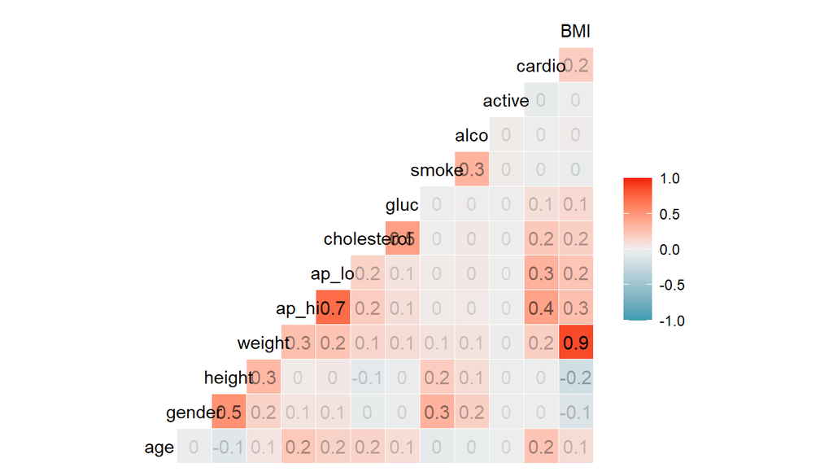

```r
#Pearson's method
a
```

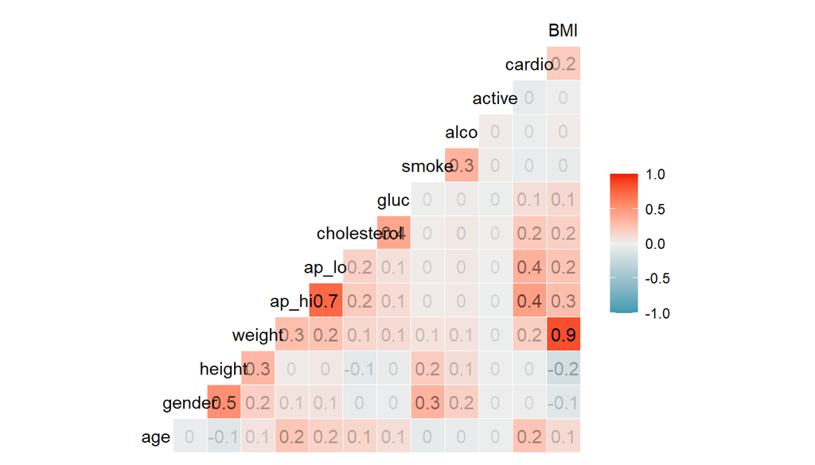

```r
#Spearman's method
b
```

```r
# It is clear that out of all the factors- glucose, cholesetrol,
#blood pressure(ap_hi and ap_lo), weight and age are the ones
#which have a positive correlation with cardio (i.e if they increase,
#chances of disease also increases), with high blood pressure
#being the most common factor for the disease.
```

### Distribution Plot of BMI w.r.t disease

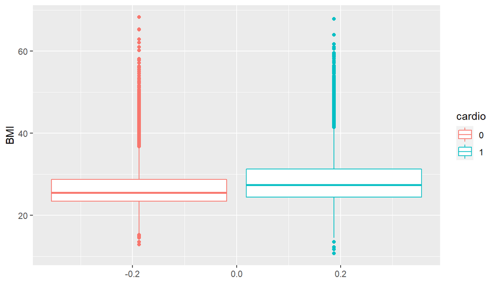

```r
ggplot(cleaned_cardio,aes(y=BMI))+geom_boxplot(aes(color=cardio))
```

```r
#Higher BMI for people having the diasease.
```